# Análisis Inteligente de Datos

Trabajo Práctico N°1

Juan Gabriel Juara

# 1 ———————————————————————–

Para la base de datos seleccionada genere una muestra aleatoria estratificada y balanceada por “depósito” de tamaño n=2000 utilizando como semilla los últimos tres dígitos del DNI/PASAPORTE. Guarde los datos en un archivo y realice todo el trabajo práctico con la muestra generada.

```r
set.seed(632)




data <- read_csv("data.csv")
data_sample <- data %>%
  group_by(deposit) %>%
  slice_sample(n = 1000)

data_sample %>%
  write_csv('data_sample.csv')

rm(data)

data_sample <- read_csv('data_sample.csv')
```

# 2 ———————————————————————–

Realice un análisis estadístico de cada una de las variables numéricas para cada valor de depósito. Presente la información en forma tabular y conteniendo las siguientes medidas descriptivas: +Cantidad de datos, +mínimo, +máximo, +media, +mediana, +moda, varianza, desviación estándar, coeficiente de variación, cuartil 1, cuartil 3, rango intercuartílico, MAD, asimetría, curtosis.

```r
data_sample <- data_sample %>%
  mutate(pdays = na_if(pdays, 999))

resumen_a <- data_sample %>%
  group_by(deposit) %>%
  summarise(
    across(everything(),list(
    tipo = ~ class(.x),
    N = ~ sum(!is.na(.x)),
    datos_faltantes = ~ sum(is.na(.x)),
    moda = ~ DescTools::Mode(.x, na.rm = T)
    ), .names = "{.col}-{.fn}")) %>%
  ungroup() %>%
      pivot_longer(cols = -c(deposit),
                   names_to = c("var", ".value"), names_sep = "-",
                   values_transform = as.character)
resumen_b <- data_sample %>%
  group_by(deposit) %>%
  summarise(
    across(where(is.numeric),
           list(
      minimo =  ~ min(.x, na.rm = T),
      maximo = ~ max(.x, na.rm = T),
      media = ~ mean(.x, na.rm = T),
      mediana = ~ median(.x, na.rm = T),
      varianza  = ~ var(.x, na.rm = T),
      desviacion_estandar = ~ sd(.x, na.rm = T),
      cv =  ~ sd(.x, na.rm = T)/mean(.x, na.rm = T),
      q1 = ~ quantile(.x, probs = .25, na.rm = T),
      q3 = ~ quantile(.x, probs = .75, na.rm = T),
      rango_iq = ~ IQR(.x, na.rm = T),
      asimetria = ~ DescTools::Skew(.x, na.rm = T),
      curtosis = ~ DescTools::Kurt(.x, na.rm = T)
    ),
    .names = "{.col}-{.fn}"
    )
    ) %>% ungroup() %>%
  pivot_longer(cols = -c(deposit),
                       names_to = c("var", ".value"), names_sep = "-",
  values_transform = as.character)

resumen <- left_join(resumen_a, resumen_b)
resumen %>%
  DT::datatable()
```

|  | deposit | var | tipo | N | datos_faltantes | moda | minimo | maximo | media | mediana | varianza | desviacion_estandar | cv | q1 | q3 | rango_iq | asimetria | curtosis |
| --- | --- | --- | --- | --- | --- | --- | --- | --- | --- | --- | --- | --- | --- | --- | --- | --- | --- | --- |
| 1 | no | age | numeric | 1000 | 0 | 35 | 19 | 87 | 40.792 | 39 | 101.924660660661 | 10.0957743962839 | 0.24749397912051 | 33 | 48 | 15 | 0.711174370191911 | 0.562346415694027 |
| 2 | no | job | character | 1000 | 0 | management |  |  |  |  |  |  |  |  |  |  |  |  |
| 3 | no | marital | character | 1000 | 0 | married |  |  |  |  |  |  |  |  |  |  |  |  |
| 4 | no | education | character | 1000 | 0 | secondary |  |  |  |  |  |  |  |  |  |  |  |  |
| 5 | no | default | character | 1000 | 0 | no |  |  |  |  |  |  |  |  |  |  |  |  |
| 6 | no | balance | numeric | 1000 | 0 | 0 | -2712 | 51439 | 1265.187 | 416 | 8396070.15418519 | 2897.59730711243 | 2.2902521975901 | 52.25 | 1351 | 1298.75 | 7.59904535998368 | 99.6788926914929 |
| 7 | no | housing | character | 1000 | 0 | yes |  |  |  |  |  |  |  |  |  |  |  |  |
| 8 | no | loan | character | 1000 | 0 | no |  |  |  |  |  |  |  |  |  |  |  |  |
| 9 | no | contact | character | 1000 | 0 | cellular |  |  |  |  |  |  |  |  |  |  |  |  |
| 10 | no | day | numeric | 1000 | 0 | 20 | 1 | 31 | 15.869 | 16 | 69.4873263263263 | 8.33590584917598 | 0.525294968125023 | 8 | 21 | 13 | 0.102707821172316 | -1.07368184925371 |

[output cut: 70 more lines]

# 3 ———————————————————————–

Represente gráficamente cada variable numérica eligiendo el gráfico que considere apropiado. Considere la posibilidad de generar rangos de datos para su análisis y representación gráfica de las variables.

```r
vars_numeric <- data_sample %>% select(where(is.numeric)) %>% colnames()

print(vars_numeric)
```

```
## [1] "age"      "balance"  "day"      "duration" "campaign" "pdays"    "previous"
```

Age

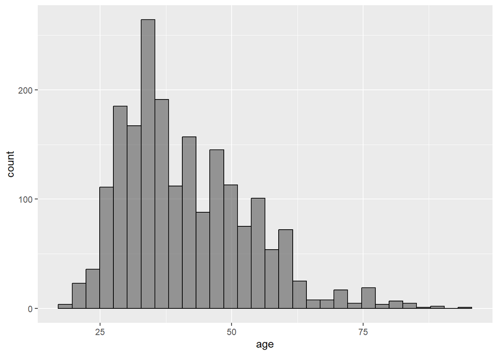

```r
data_sample %>%
  ggplot() +
    geom_histogram(aes(age),
                   color = "black",
                   alpha = .6, position = "identity")
```

Balance

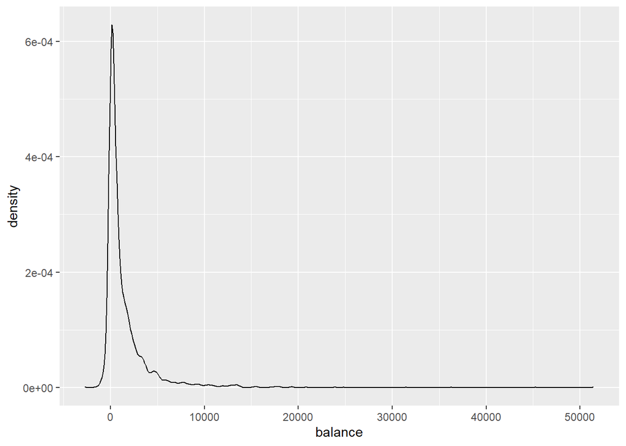

```r
data_sample %>%
  ggplot() +
  geom_density(aes(x = balance))
```

pdays

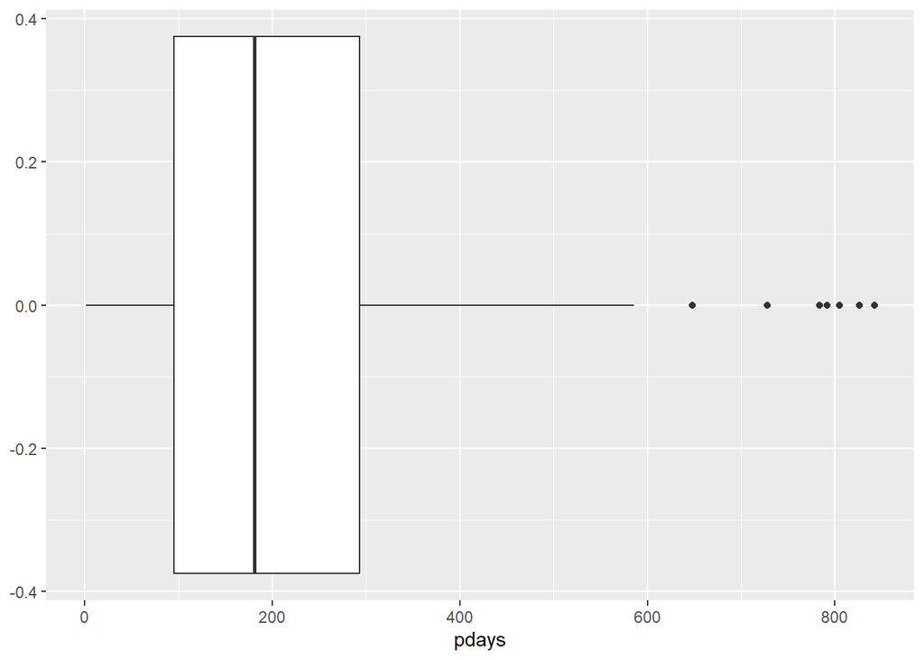

```r
#' pdays: number of days that passed by after the client was
#' last contacted from a previous campaign (numeric; 999 means
#' client was not previously contacted)

data_sample %>%
  ggplot() +
  geom_boxplot(aes(pdays))
```

previous

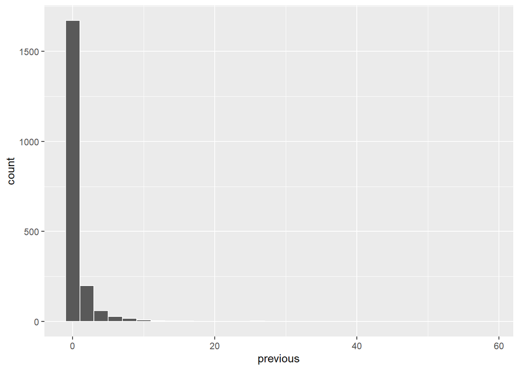

```r
#' previous: number of contacts performed before
#' this campaign and for this client (numeric)

data_sample %>%
  ggplot() +
  geom_histogram(aes(previous),
                 color = "white")
```

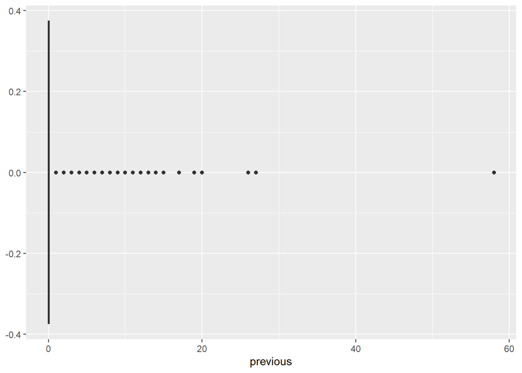

```r
data_sample %>%
  ggplot() +
  geom_boxplot(aes(previous))
```

Campaing

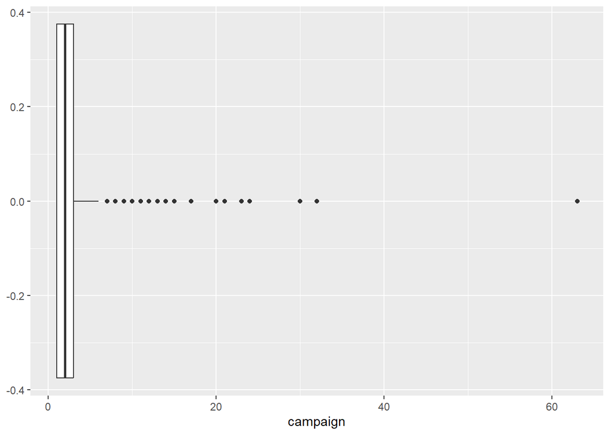

```r
#' campaign: number of contacts performed during this campaign
#' and for this client (numeric, includes last contact)

data_sample %>%
  ggplot() +
  geom_boxplot(aes(campaign))
```

day

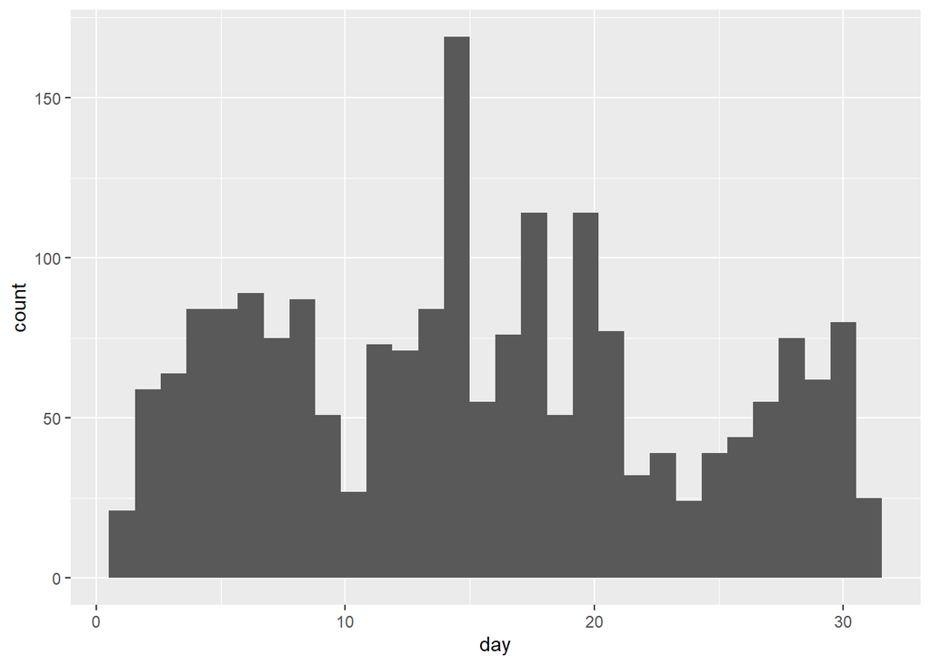

```r
data_sample %>%
  ggplot() +
  geom_histogram(aes(day))
```

duration

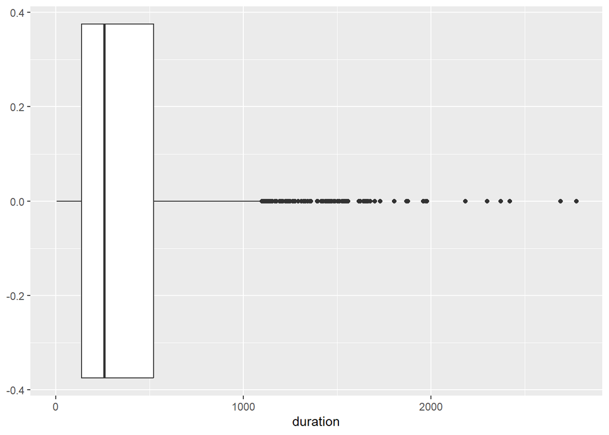

```r
#'duration: last contact duration, in seconds (numeric).

data_sample %>%
  ggplot() +
  geom_boxplot(aes(duration))
```

# 4 ———————————————————————–

Presente una tabla de frecuencias y porcentaje para la variable “marital” (estado civil) según el nivel de la variable “deposit”.

```r
data_sample %>%
  count(deposit, marital) %>% class()
```

```
## [1] "tbl_df"     "tbl"        "data.frame"
```

```r
DescTools::PercTable(tab = table(data_sample$marital,
                                 data_sample$deposit),
                     margins = c(1,2))
```

```
##
##                     no    yes    Sum
##
## divorced   freq     98    108    206
##            perc   4.9%   5.4%  10.3%
##
## married    freq    639    530  1'169
##            perc  31.9%  26.5%  58.5%
##
## single     freq    263    362    625
##            perc  13.2%  18.1%  31.2%
##
## Sum        freq  1'000  1'000  2'000
##            perc  50.0%  50.0% 100.0%
##
```

# 5 ———————————————————————–

Realice un gráfico para representar la tabla construida en el punto 4.

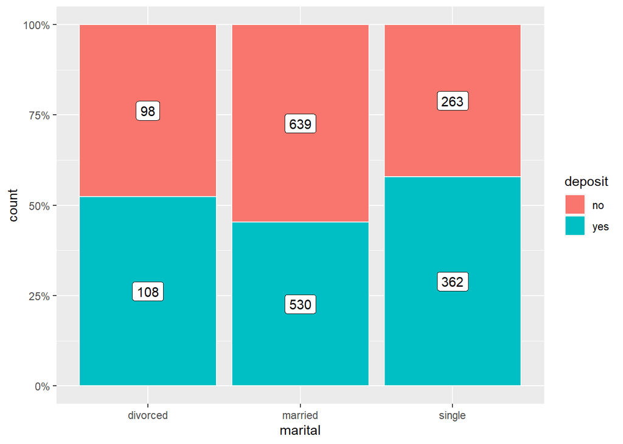

```r
data_sample %>%
  ggplot() +
  geom_bar(aes(x = marital, fill = deposit), position = "fill", color = "white") +
  geom_label(aes(x = marital, y = after_stat(count),
                 label = after_stat(count), group = deposit),
            stat = "count", position = position_fill(vjust = .5)) +
  scale_y_continuous(labels = ~ scales::label_percent()(.x))
```

# 6 ———————————————————————–

Elija dos variables continuas, establezca rangos que representen distintos niveles de cada una y defina nuevas variables categóricas. Aplique un test adecuado para entender si existe asociación entre ambas. Utilice un nivel de significación del 5%.

```r
quantile(data_sample$age, probs = c(.25, .5,.75))
```

```
## 25% 50% 75%
##  32  39  49
```

```r
quantile(data_sample$balance, probs = c(.25, .5,.75))
```

```
##     25%     50%     75%
##  116.75  554.50 1737.75
```

```r
test_data_balance_age <- data_sample %>%
  mutate(age_bin = cut(age, breaks = c(19, 30, 60, max(age)), include.lowest = T),
         balance_bin = cut(balance, breaks = c(min(balance), quantile(balance,
                                                                     probs = c(.25, .75)),
                                                   max(balance)),
                           include.lowest = T)) %>%
  select(age_bin, balance_bin)

table_balance_age <- table(test_data_balance_age$balance_bin, test_data_balance_age$age_bin)
table_balance_age
```

```
##
##                       [19,30] (30,60] (60,95]
##   [-2.71e+03,117]          83     406      11
##   (117,1.74e+03]          198     749      53
##   (1.74e+03,5.14e+04]      78     371      51
```

```r
prop.table(table_balance_age, margin = c(2))
```

```
##
##                          [19,30]    (30,60]    (60,95]
##   [-2.71e+03,117]     0.23119777 0.26605505 0.09565217
##   (117,1.74e+03]      0.55153203 0.49082569 0.46086957
##   (1.74e+03,5.14e+04] 0.21727019 0.24311927 0.44347826
```

H0: las variables son independientes Ha: las variables no son independites

```r
chi_balance_age <- chisq.test(table_balance_age)

print("hay valores esperados iguales a cero?")
```

```
## [1] "hay valores esperados iguales a cero?"
```

```r
print(any(chi_balance_age$expected == 0))
```

```
## [1] FALSE
```

```r
print(sum(chi_balance_age$expected < 5)/length(chi_balance_age$expected))
```

```
## [1] 0
```

```r
print(glue::glue("p valor  = {chi_balance_age$p.value}"))
```

```
## p valor  = 5.60627943912828e-07
```

Se rechaza la hipótesis nula: hay evidencia estadística de que las variables no son independientes.

# 7 ———————————————————————–

Seleccione la variable “education” y elija otra variable categórica. Aplique un test adecuado para entender si existe asociación entre ambas. Utilice un nivel de significación del 5%.

```r
# tabla de contingencia
table_education <- table(data_sample$education,
      data_sample$default)
```

test de Chi cuadrado Ho: las variables son independientes Ha: las variables no son independientes

```r
chi_education_default <- chisq.test(table_education)
# warning de posible aproximacion incorrecta
```

```r
print(chi_education_default )
```

```
##
##  Pearson's Chi-squared test
##
## data:  table_education
## X-squared = 5.0785, df = 3, p-value = 0.1661
```

```r
print(chi_education_default$expected)
```

```
##
##                 no   yes
##   primary   272.44  5.56
##   secondary 950.60 19.40
##   tertiary  649.74 13.26
##   unknown    87.22  1.78
```

hay valores esperados menores a 5: posible origen del warning

Se decide evaluar con test exacto de Fisher con alfa = 0.05 Ho: las variables son independientes Ha: las variables no son independientes

```r
fisher.test(table_education)
```

```
##
##  Fisher's Exact Test for Count Data
##
## data:  table_education
## p-value = 0.1421
## alternative hypothesis: two.sided
```

p valor no permite rechazar la hipostesis nula, se asume la independencia de las variables.

# 8 ———————————————————————–

Seleccione otra variable continua y estime la diferencia de medias según el valor de la variable “deposit” con un nivel de confianza del 95%. Interprete el resultado obtenido.

test de normalidad con alfa = 0.05 Ho = la variable sigue una distribución normal Ha = la variable no sigue una distribución normal

```r
shapiro.test(data_sample$duration[data_sample$deposit == "no"])
```

```
##
##  Shapiro-Wilk normality test
##
## data:  data_sample$duration[data_sample$deposit == "no"]
## W = 0.75361, p-value < 2.2e-16
```

```r
shapiro.test(data_sample$duration[data_sample$deposit == "yes"])
```

```
##
##  Shapiro-Wilk normality test
##
## data:  data_sample$duration[data_sample$deposit == "yes"]
## W = 0.87275, p-value < 2.2e-16
```

p-valor permite rechazar la hipotesis nula en ambos casos, las muestras no siguen una distribucion normal

se testea si hay homocedasticidad: test de varianzas de Levene para muestras no normales se prueba si las varianzas desconocidas son diferentes bajo un alfa de 0.05. H0: las varianzas son iguales Ha: las varianzas son diferentes

```r
var_test <- leveneTest(duration ~ as_factor(deposit),
                       data=data_sample, alternative = "two.sided")

var_test
```

```
## Levene's Test for Homogeneity of Variance (center = median: "two.sided")
##         Df F value    Pr(>F)
## group    1   245.7 < 2.2e-16 ***
##       1998
## ---
## Signif. codes:  0 '***' 0.001 '**' 0.01 '*' 0.05 '.' 0.1 ' ' 1
```

p valor permite rechazar la hipotesis nula. se asume varianzas diferentes. Se decide utilizar el estadístico Z basado en la varianza muestral para muestras grandes con varianza poblacional desconocida.

```r
BSDA::z.test(data_sample$duration[data_sample$deposit == "no"],
             data_sample$duration[data_sample$deposit == "yes"],
             alternative = "two.sided",
             conf.level = 0.05,
             sigma.x = sd(data_sample$duration[data_sample$deposit == "no"]),
             sigma.y = sd(data_sample$duration[data_sample$deposit == "yes"]))
```

```
##
##  Two-sample z-Test
##
## data:  data_sample$duration[data_sample$deposit == "no"] and data_sample$duration[data_sample$deposit == "yes"]
## z = -23.482, p-value < 2.2e-16
## alternative hypothesis: true difference in means is not equal to 0
## 5 percent confidence interval:
##  -339.1051 -337.2989
## sample estimates:
## mean of x mean of y
##   217.563   555.765
```

# 9 ———————————————————————–

Según el resultado obtenido en el punto 8.- realice un test de hipótesis apropiado para determinar la diferencia de medias de la variable en estudio. Trabaje con una significación del 5%. Presente el planteo de hipótesis adecuado, la resolución y la decisión a tomar.

Se utiliza un test de hipótesis basado en el estadístico Z para muestras grandes de poblaciones con varianza desconocida

H0: la diferencia de medias es igual a cero, Ha: la diferencia de medias es distinta de cero

```r
BSDA::z.test(data_sample$duration[data_sample$deposit == "no"],
             data_sample$duration[data_sample$deposit == "yes"],
             alternative = "two.sided",
             conf.level = 0.05,
             sigma.x = sd(data_sample$duration[data_sample$deposit == "no"]),
             sigma.y = sd(data_sample$duration[data_sample$deposit == "yes"]))
```

```
##
##  Two-sample z-Test
##
## data:  data_sample$duration[data_sample$deposit == "no"] and data_sample$duration[data_sample$deposit == "yes"]
## z = -23.482, p-value < 2.2e-16
## alternative hypothesis: true difference in means is not equal to 0
## 5 percent confidence interval:
##  -339.1051 -337.2989
## sample estimates:
## mean of x mean of y
##   217.563   555.765
```

el p-valor obtenido permite rechazar H0, se asume que la diferencia de medias es distinta de cero

# 10 ———————————————————————-

10. Seleccione una muestra de 30 elementos estratificada según la variable “deposit”. ¿Se puede afirmar que hay diferencias significativas en el balance de los que realizaron el depósito respecto a aquellos que no lo hicieron? Elija un test de hipótesis adecuado. Trabaje con una significación del 5%.

```r
submuestra <- data_sample %>%
  slice_sample(n = 15, by = deposit)
```

testeo normalidad h0: la variable tiene distribucion normal ha: la variable no tiene distribucion normal

```r
shapiro.test(submuestra$balance)
```

```
##
##  Shapiro-Wilk normality test
##
## data:  submuestra$balance
## W = 0.52574, p-value = 1.014e-08
```

p valor permite rechazar la hipotesis nula, se asume que la variable no tiene una distribucion normal. dado: muestra pequeña, distribucion no normal y variable numerica, se opta por un test no parametrico

H0: no hay diferencias de poblacion para balance entre deposit yes y deposit no Ha: hay diferencias de poblacion para balance entre deposit yes y deposit no

```r
wilcox.test(submuestra$balance[submuestra$deposit == 'no'],
            y = submuestra$balance[submuestra$deposit == 'yes'],
            exact = F, # aproximacion normal al p valor para muestras con empates
            digits.rank = 5,
            alternative = "two.sided")
```

```
##
##  Wilcoxon rank sum test with continuity correction
##
## data:  submuestra$balance[submuestra$deposit == "no"] and submuestra$balance[submuestra$deposit == "yes"]
## W = 84.5, p-value = 0.2535
## alternative hypothesis: true location shift is not equal to 0
```

el p valor no permite rechazar la hipotesis nula: se asume que no hay diferencias significativas en el balance de los que realizaron el depósito respecto a aquellos que no lo hicieron se asume que ambas muestras de balance provienen de poblaciones identicas

# 11 ———————————————————————-

11. Decida si existen diferencias significativas en la duración respecto los niveles de educación (“secondary”, “tertiary”, “primary”, “unknown”). Justifique. Utilice un test adecuado. Realice las pruebas necesarias para comprobar los supuestos. Trabaje con una significación del 5%.

Pruebo con Anova. Supuestos: - Las muestras deben ser aleatorias y las observaciones independientes (asumo probado por origen de muestras) - Las varianzas de las subpoblaciones deben ser iguales (homocedasticidad) a testear - La distribución de cada subpoblación es normal a testear

```r
modelo <- aov(duration ~ factor(education),
            data=data_sample)
```

chequeo homocedasticidad a nivel de sig 0.05

```r
leveneTest(duration ~ as_factor(education), data = data_sample)
```

```
## Levene's Test for Homogeneity of Variance (center = median)
##         Df F value Pr(>F)
## group    3  2.0721 0.1019
##       1996
```

el p valor indica que no hay evidencia para rechazar la hipotesis nula: se asume que las varianzas son iguales

chequeo normalidad por test de normalidad sobre los residuos a nivel de significacion 0.05 h0: los residuos tienen distribucion normal ha: los residuos no tienen distribucion normal

```r
shapiro.test(modelo$residuals)
```

```
##
##  Shapiro-Wilk normality test
##
## data:  modelo$residuals
## W = 0.81323, p-value < 2.2e-16
```

p valor indica que hay evidencia para rechazar la hipotesis nula de que los residuos se distribuyen normalmente. Se descarta el modelo de anova y pasamos a una prueba no parametrica

pruebo con test de Kruskal-Wallis para k grupos con nivel de significancia 0.05 Ho: todos los niveles educativos tienen una posicion central similar para la variable duration Ha al menos un nivel educativo tiene una posicion central diferente para la variable duration

```r
kruskal.test(duration ~ as_factor(education), data = data_sample)# Realiza el test de Kruskal Wallis
```

```
##
##  Kruskal-Wallis rank sum test
##
## data:  duration by as_factor(education)
## Kruskal-Wallis chi-squared = 2.0547, df = 3, p-value = 0.5611
```

p valor indica que no hay evidencia para rechazar hipotesis nula. Se asume una posicion central para la variable duracion igual entre los diferentes niveles educativos

# 12 ———————————————————————-

12. Elija dos variables cuantitativas, determine la variable explicativa y la variable explicada. Encuentre la ecuación de la recta de regresión lineal que explique la relación entre las variables elegidas. Escriba conclusiones acerca de la significatividad del modelo aplicado. Puede acompañar el modelo de un gráfico adecuado.

Se elije age como variable explicativa y duration como variable explicada.

```r
lm_modelo <- lm(duration ~ age, data = data_sample)

summary(lm_modelo)
```

```
##
## Call:
## lm(formula = duration ~ age, data = data_sample)
##
## Residuals:
##    Min     1Q Median     3Q    Max
## -390.5 -246.9 -128.9  138.6 2378.3
##
## Coefficients:
##             Estimate Std. Error t value Pr(>|t|)
## (Intercept) 420.2969    28.9867  14.500   <2e-16 ***
## age          -0.8146     0.6739  -1.209    0.227
## ---
## Signif. codes:  0 '***' 0.001 '**' 0.01 '*' 0.05 '.' 0.1 ' ' 1
##
## Residual standard error: 363.7 on 1998 degrees of freedom
## Multiple R-squared:  0.0007308,  Adjusted R-squared:  0.0002307
## F-statistic: 1.461 on 1 and 1998 DF,  p-value: 0.2269
```

Sin embargo los estadísticos del modelo parecen indicar que la relación no es significativa.